# ChatGPT Review sentiment Analysis

# Onkar Pednekar - Sentiment Analysis

Link to dataset: https://www.kaggle.com/datasets/charunisa/chatgpt-sentiment-analysis?resource=download

#### About the dataset:

The "ChatGPT Sentiment Analysis" dataset consists of tweets that mention ChatGPT, a well-known AI language model, and is labeled with sentiment scores that indicate whether each tweet is good, bad or neutral in sentiment. The dataset presents a timely and pertinent issue for studying public attitude about this cutting-edge technology and consists of a significant amount of tweets. The dataset consists of 2 columns ie tweets and labels. The dataset is unstructured.

#### Why I chose the dataset:

I selected the "ChatGPT Sentiment Analysis" dataset because I was keen on finding out how people see ChatGPT and how it is utilized in different circumstances, which is why I was drawn to this dataset. Understanding how individuals feel about ChatGPT might help determine how the model should be improved or tailored to better suit user requirements.

This dataset also poses unique problems for sentiment analysis due to factors such as class imbalance and noise. Class imbalance may be an issue since there are quite a lot of posts with sentiment ratings of positive, negative, or neutral. There may be a big variation in how many tweets fall into each sentiment group. Additionally, noise like sarcasm, irony, or irrelevant tweets might make sentiment analysis more difficult. Despite these difficulties, the dataset offers a great chance for experimenting with and improving different NLP methods for dealing with noise and class imbalance. I decided to take on the task of working with this dataset because I wanted to learn more about how people feel about ChatGPT and come up with solutions to the problems it brings.

```python
import pandas as pd
import numpy as np
from nltk.tokenize import word_tokenize
from nltk.corpus import stopwords, wordnet
from nltk.stem import WordNetLemmatizer
import matplotlib.pyplot as plt
from wordcloud import WordCloud, STOPWORDS
from tqdm import tqdm
import time
from sklearn.feature_extraction.text import TfidfVectorizer
from sklearn.model_selection import train_test_split
from sklearn.preprocessing import LabelEncoder
from sklearn.metrics import precision_score, recall_score, f1_score, accuracy_score
import joblib

import matplotlib.gridspec as gridspec
import xgboost as xgb
from sklearn.linear_model import LogisticRegression
from sklearn.tree import DecisionTreeClassifier
from sklearn.ensemble import RandomForestClassifier
from sklearn.naive_bayes import MultinomialNB
from sklearn.ensemble import GradientBoostingClassifier
import nltk

nltk.download(['punkt','stopwords','wordnet','omw-1.4','averaged_perceptron_tagger'])
```

```
True
```

# num_rows means how many rows of data to include in answer. Keep value low for faster execution of code

```python
num_rows = 30000
df = pd.read_csv('file.csv')[['tweets','labels']]
df = df[df['labels'] != 'neutral'].reset_index(drop=True)[:num_rows]
df['labels'] = df['labels'].replace({'good': 'positive', 'bad': 'negative'})
df
```

|  | tweets | labels |
| --- | --- | --- |
| 0 | Try talking with ChatGPT, our new AI system wh... | positive |
| 1 | THRILLED to share that ChatGPT, our new model ... | positive |
| 2 | As of 2 minutes ago, @OpenAI released their ne... | negative |
| 3 | Just launched ChatGPT, our new AI system which... | positive |
| 4 | As of 2 minutes ago, @OpenAI released their ne... | negative |
| ... | ... | ... |
| 29995 | Ah geeze…after a few swipes on the feed, our b... | positive |
| 29996 | A look at the implications of OpenAI's ChatGPT... | negative |
| 29997 | Is there a way to make ChatGPT RTFM? I'm askin... | negative |
| 29998 | Augmenting the think-pair-share with ChatGPT c... | positive |
| 29999 | With ChatGPT, we basically all have a Jarvis.\... | negative |

30000 rows × 2 columns

### Data Preprocessing

Converting text to lowercase

```python
df['tweets'] = df.tweets.str.lower()
df
```

|  | tweets | labels |
| --- | --- | --- |
| 0 | try talking with chatgpt, our new ai system wh... | positive |
| 1 | thrilled to share that chatgpt, our new model ... | positive |
| 2 | as of 2 minutes ago, @openai released their ne... | negative |
| 3 | just launched chatgpt, our new ai system which... | positive |
| 4 | as of 2 minutes ago, @openai released their ne... | negative |
| ... | ... | ... |
| 29995 | ah geeze…after a few swipes on the feed, our b... | positive |
| 29996 | a look at the implications of openai's chatgpt... | negative |
| 29997 | is there a way to make chatgpt rtfm? i'm askin... | negative |
| 29998 | augmenting the think-pair-share with chatgpt c... | positive |
| 29999 | with chatgpt, we basically all have a jarvis.\... | negative |

30000 rows × 2 columns

```python
tweets = df.tweets.values
y = np.array(df.labels)
```

Tokenization: We will break down sentences into single words (tokens) since we would be using words for tasks in the future. To do so, we used the word tokenizer available in nltk

Make lowercase and remove punctuation:

1. We remove irrelevant characters like punctuations. To do so, we check if the word is alphanumeric or not thus using only words and omitting punctuations.
2. To remove redundancy we make the words lowercase so words like "DeviCEs" and "devices" are considered to be same and redundancy is removed.

```python
def remove_stopwords(tweets):
    stop_words = stopwords.words('english')
    data = [[word.lower() for word in word_tokenize(sent) if ((word.isalpha()) and word not in stop_words)] for sent in tqdm(tweets)]
    return data
data = remove_stopwords(tweets)
print(data[0])
```

```
['try', 'talking', 'chatgpt', 'new', 'ai', 'system', 'optimized', 'dialogue', 'feedback', 'help', 'us', 'improve', 'https']
```

Performing lemmatization to remove redundancy and convert all words to base form

```python
def lemmatize(data):
    lemmatizer = WordNetLemmatizer()
    tweets_pos = [nltk.pos_tag(tweet) for tweet in tqdm(data)]
    tweets_lemma = [[lemmatizer.lemmatize(word, pos=wordnet_pos(tag)) for word, tag in pos_tags] for pos_tags in tqdm(tweets_pos)]
    return tweets_lemma

def lemmatize_words(words, pos_tags):
    return [lemmatizer.lemmatize(word, pos=wordnet_pos(tag)) for word, tag in zip(words, pos_tags)]

def wordnet_pos(pos_tag):
    if pos_tag.startswith('J'):
        return wordnet.ADJ
    elif pos_tag.startswith('V'):
        return wordnet.VERB
    elif pos_tag.startswith('N'):
        return wordnet.NOUN
    elif pos_tag.startswith('R'):
        return wordnet.ADV
    else:
        return wordnet.NOUN

data = lemmatize(data)
print(data[0])
```

```
['try', 'talk', 'chatgpt', 'new', 'ai', 'system', 'optimize', 'dialogue', 'feedback', 'help', 'u', 'improve', 'http']
```

Using TfIDF vectorizer

```python
def get_TFIDF_vectors(tweets_lemma):
    vectorizer = TfidfVectorizer()
    lists = [" ".join(row) for row in tweets_lemma]
    vectorizer.fit(lists)
    tfidf_matrix = vectorizer.transform(lists)
    X = tfidf_matrix.toarray()
    return vectorizer,X

vectorizer, X = get_TFIDF_vectors(data)
print(X)
```

```
[[0. 0. 0. ... 0. 0. 0.]
 [0. 0. 0. ... 0. 0. 0.]
 [0. 0. 0. ... 0. 0. 0.]
 ...
 [0. 0. 0. ... 0. 0. 0.]
 [0. 0. 0. ... 0. 0. 0.]
 [0. 0. 0. ... 0. 0. 0.]]
```

Using label encoding to change categorical data to numbers

```python
def encodeLabels(y):
    encoder = LabelEncoder()
    encoder = encoder.fit(y)
    Y = encoder.transform(y)
    return encoder,Y

encoder, Y = encodeLabels(y)
print('Shape of input data is: ',X.shape)
print('Shape of labels is: ',y.shape)
```

```
Shape of input data is:  (30000, 21194)
Shape of labels is:  (30000,)
```

### Data splitting

```python
X_train, X_test, y_train, y_test = train_test_split(X, Y, test_size=0.2, stratify=y)
print('Shape of training data is: ',X_train.shape)
print('Shape of training labels is: ',y_train.shape)
print('Shape of testing data is: ',X_test.shape)
print('Shape of testing labels is: ',y_test.shape)
```

```
Shape of training data is:  (24000, 21194)
Shape of training labels is:  (24000,)
Shape of testing data is:  (6000, 21194)
Shape of testing labels is:  (6000,)
```

### Visualizing data

Checking if there is imabalnce in target variable

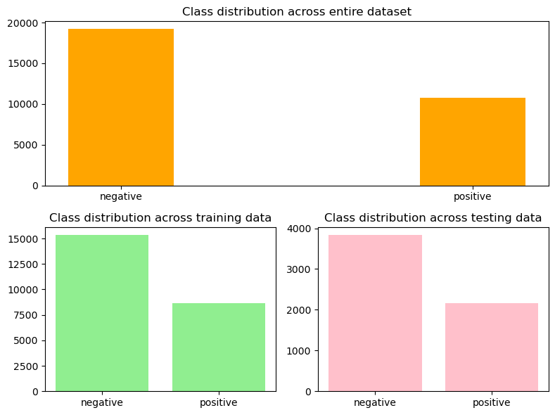

```python
fig = plt.figure(figsize=(8, 6))
gs = gridspec.GridSpec(2, 2)
ax1 = fig.add_subplot(gs[0, :])
unique, counts = np.unique(y, return_counts=True)
ax1.bar([0,1],counts, color = 'orange',width=0.3)
ax1.set_title('Class distribution across entire dataset')
ax1.set_xticks([0,1],unique)

ax2 = fig.add_subplot(gs[1, 0])
_, counts = np.unique(y_train, return_counts=True)
ax2.bar([0,1],counts, color = 'lightgreen')
ax2.set_xticks([0,1],unique)
ax2.set_title('Class distribution across training data')


ax3 = fig.add_subplot(gs[1, 1])
_, counts = np.unique(y_test, return_counts=True)
ax3.bar([0,1],counts, color = 'pink')
ax3.set_xticks([0,1],unique)
ax3.set_title('Class distribution across testing data')

plt.tight_layout()
plt.show()
```

Drawing wordcloud to get insights about dataset

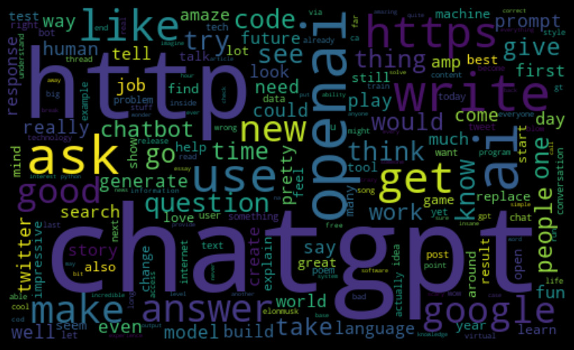

```python
text = ' '.join(word for sent in data for word in sent)
from collections import Counter
word_counts = Counter(text.split())
wordcloud = WordCloud(
    width = 500,
    height = 300,
    background_color = 'black',
    stopwords = STOPWORDS).generate_from_frequencies(word_counts)
fig = plt.figure(
    figsize = (8, 6),
    facecolor = 'k',
    edgecolor = 'k')
plt.imshow(wordcloud, interpolation = 'bilinear')
plt.axis('off')
plt.tight_layout(pad=0)
plt.show()
```

### Developing model

XGBoost

```python
xgbClassifier = xgb.XGBClassifier()
xgbClassifier.fit(X_train, y_train)
y_pred = xgbClassifier.predict(X_test)
XGBaccuracy = accuracy_score(y_test, y_pred)
XGBprecision = precision_score(y_test, y_pred)
XGBrecall = recall_score(y_test, y_pred)
XGBf1 = f1_score(y_test, y_pred)
print('Precision is: ',XGBprecision)
print('Accuracy is: ',XGBaccuracy)
print('Recall is: ',XGBrecall)
print('F1 is: ',XGBf1)
```

[output not shown]

Logistic Regression

```python
logreg = LogisticRegression(verbose=1)
logreg.fit(X_train, y_train)
y_pred = logreg.predict(X_test)
LRaccuracy = accuracy_score(y_test, y_pred)
LRprecision = precision_score(y_test, y_pred)
LRrecall = recall_score(y_test, y_pred)
LRf1 = f1_score(y_test, y_pred)
print('Precision is: ',LRprecision)
print('Accuracy is: ',LRaccuracy)
print('Recall is: ',LRrecall)
print('F1 is: ',LRf1)
joblib.dump(logreg, 'logistic_regression_weights.pkl')
```

```
[Parallel(n_jobs=1)]: Using backend SequentialBackend with 1 concurrent workers.
[Parallel(n_jobs=1)]: Done   1 out of   1 | elapsed:  1.1min finished
```

```
Precision is:  0.9360495100567303
Accuracy is:  0.9215
Recall is:  0.8395004625346901
F1 is:  0.8851499634235552
```

```
['logistic_regression_weights.pkl']
```

Decision Tree

```python
decTree = DecisionTreeClassifier()
decTree.fit(X_train, y_train)
y_pred = decTree.predict(X_test)
DTaccuracy = accuracy_score(y_test, y_pred)
DTprecision = precision_score(y_test, y_pred)
DTrecall = recall_score(y_test, y_pred)
DTf1 = f1_score(y_test, y_pred)
print('Precision is: ',DTprecision)
print('Accuracy is: ',DTaccuracy)
print('Recall is: ',DTrecall)
print('F1 is: ',DTf1)
```

```
Precision is:  0.8318505338078291
Accuracy is:  0.8883333333333333
Recall is:  0.8649398704902868
F1 is:  0.8480725623582767
```

Random Forest

```python
randomForest = RandomForestClassifier(verbose=1)
randomForest.fit(X_train, y_train)
y_pred = randomForest.predict(X_test)
RFaccuracy = accuracy_score(y_test, y_pred)
RFprecision = precision_score(y_test, y_pred)
RFrecall = recall_score(y_test, y_pred)
RFf1 = f1_score(y_test, y_pred)
print('Precision is: ',RFprecision)
print('Accuracy is: ',RFaccuracy)
print('Recall is: ',RFrecall)
print('F1 is: ',RFf1)
```

```
[Parallel(n_jobs=1)]: Using backend SequentialBackend with 1 concurrent workers.
[Parallel(n_jobs=1)]: Done 100 out of 100 | elapsed: 27.4min finished
[Parallel(n_jobs=1)]: Using backend SequentialBackend with 1 concurrent workers.
```

```
Precision is:  0.8673982624599909
Accuracy is:  0.9075
Recall is:  0.8774283071230342
F1 is:  0.8723844561968269
```

```
[Parallel(n_jobs=1)]: Done 100 out of 100 | elapsed:    2.3s finished
```

Multinomial Naive Bayes

```python
multiNB = MultinomialNB()
multiNB.fit(X_train, y_train)
y_pred = multiNB.predict(X_test)
MNBaccuracy = accuracy_score(y_test, y_pred)
MNBprecision = precision_score(y_test, y_pred)
MNBrecall = recall_score(y_test, y_pred)
MNBf1 = f1_score(y_test, y_pred)
print('Precision is: ',MNBprecision)
print('Accuracy is: ',MNBaccuracy)
print('Recall is: ',MNBrecall)
print('F1 is: ',MNBf1)
```

```
Precision is:  0.9405204460966543
Accuracy is:  0.8766666666666667
Recall is:  0.7021276595744681
F1 is:  0.8040254237288136
```

[figure not shown]

```python
fig,ax = plt.subplots(figsize = (8,6))
ax.plot([XGBaccuracy,LRaccuracy,DTaccuracy,RFaccuracy,MNBaccuracy],linewidth=2.5, c = 'red', label = 'Accuracy')
ax.plot([XGBprecision,LRprecision,DTprecision,RFprecision,MNBprecision],linewidth=2.5, c = 'orange', label = 'Precision')
ax.plot([XGBrecall,LRrecall,DTrecall,RFrecall,MNBrecall],linewidth=2.5, c = 'gray', label = 'Recall')
ax.plot([XGBf1,LRf1,DTf1,RFf1,MNBf1],linewidth=2.5, c = 'navy', label = 'F1 score')
ax.set_xticks([0,1,2,3,4],labels = ['XG Boost', 'Logistic Regression', 'Decision Trees', 'Random Forest','Multinomial Naive Bayes'])
ax.legend(markerscale=1,edgecolor='black')
plt.grid()
plt.show()
```

### We will choose Logistic Regression since it has best accuracy

### Performing prediction on new data

Load model to use

```python
model = joblib.load('logistic_regression_weights.pkl')
```

Preprocess the input and perform prediction

```python
def predictReview(review,vectorizer,encoder):
    reviewProcessed = remove_stopwords([review])
    reviewLemma = lemmatize(reviewProcessed)
    reviewTFIDF = vectorizer.transform([" ".join(word) for word in reviewLemma]).toarray()
    print('Shape of input review is: ', reviewTFIDF.shape)
    pred = model.predict(reviewTFIDF)
    pred = encoder.inverse_transform(pred).item()
    return pred
```

Take user input

```python
review = input('Enter your review: ')
print('\nInput is: ',review)
print('\nPreprocessing data...')
pred = predictReview(review,vectorizer,encoder)
print('The input review is: ', pred)
```

```
Enter your review: ChatGPT is an incredibly helpful and intelligent AI language model that provides accurate and timely responses to all queries

Input is:  ChatGPT is an incredibly helpful and intelligent AI language model that provides accurate and timely responses to all queries

Preprocessing data...
```

```
Shape of input review is:  (1, 21194)
The input review is:  positive
```

```python
review = input('Enter your review: ')
print('\nInput is: ',review)
print('\nPreprocessing data...')
pred = predictReview(review,vectorizer,encoder)
print('The input review is: ', pred)
```

```
Enter your review:  I found ChatGPT's responses to be frequently inaccurate and irrelevant. The interface was also clunky and difficult to use, making it unsuitable for more complex queries or tasks

Input is:   I found ChatGPT's responses to be frequently inaccurate and irrelevant. The interface was also clunky and difficult to use, making it unsuitable for more complex queries or tasks

Preprocessing data...
```

```
Shape of input review is:  (1, 21194)
The input review is:  negative
```